# Who shapes the score? Reviewer expertise and engagement in grant peer review

2nd Canadian Open Science Conference – pre-conference webinar

Sam Harper (with Arijit Nandi)

2026-10-02

## The problem

**Scores decide who gets funded**  
Peer review moves billions of research dollars

**Scores come out of a conversation**  
Panel discussion can change what reviewers think

**Not everyone in that conversation is equally engaged**  
Some members read the application closely; most did not

## How CIHR Project Grant review works

**1. Three assigned reviewers read and score**  
Assigned partly on self-declared expertise (high / medium / low / not enough)

**2. The committee discusses and agrees a consensus score**  
Reviewers present; all other members are “panelists”

**3. Every member then scores privately**  
Final scores must stay within ±0.5 of consensus

CIHR Project Grant Peer Review Manual, cihr-irsc.gc.ca/e/49564.html

## Research questions

**Aim 1: Expertise and engagement**  
Do reviewers vs. panelists, and high vs. low expertise, differ in how they deviate from consensus?

**Aim 2: Whose scores move?**  
Do those patterns differ by applicant characteristics?

**Aim 3: What if?**  
Would alternative funding rules (e.g., weighting by engagement) change who is funded?

## Approach: bring the code to the data

**Restricted application-level data**  
CIHR Funding Analytics holds it; we do not see identities

**Our code runs *inside* CIHR**  
Analysts run it and return results – no interactive debugging

**So we simulate first**  
Build, test, and pre-specify the whole pipeline on synthetic data

## A two-part model for a “spike and slab” outcome

Outcome: $d_{ijk}$ = final score − consensus score

Many members simply adopt the consensus ($d = 0$); the rest vary within ±0.5.

**Part 1:** did they deviate at all?

**Part 2:** by how much, and in which direction, if they did?

$$E[d] = \underbrace{P(\text{deviate})}_{\text{Part 1: Bernoulli}} \times \underbrace{E[d \mid \text{deviate}]}_{\text{Part 2: ordinal}}$$

Bayesian multilevel models (`brms`), with committee, application and member effects

Both parts allow **role** and **expertise** to shift the *location* and, in Part 2, the *spread*

## What the simulated data look like

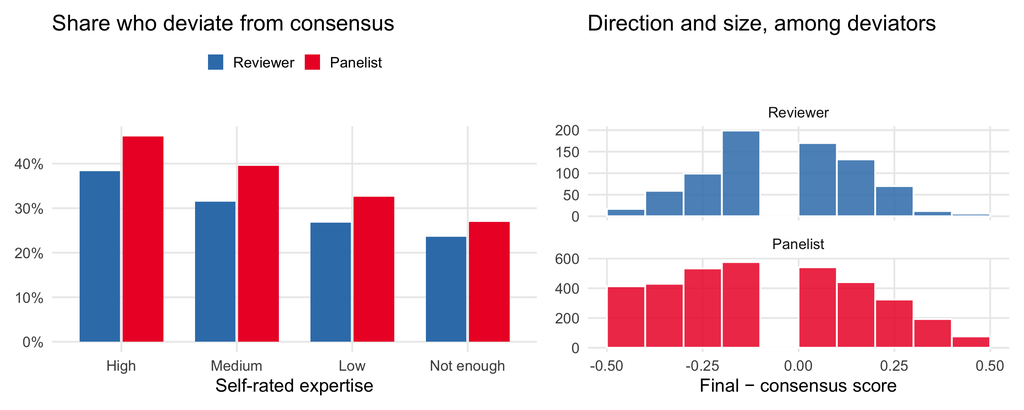

**Simulated** data only – built from public CIHR process descriptions; no real applicant or reviewer data are shown.

## Lesson 1: draw the causal diagram *before* choosing covariates

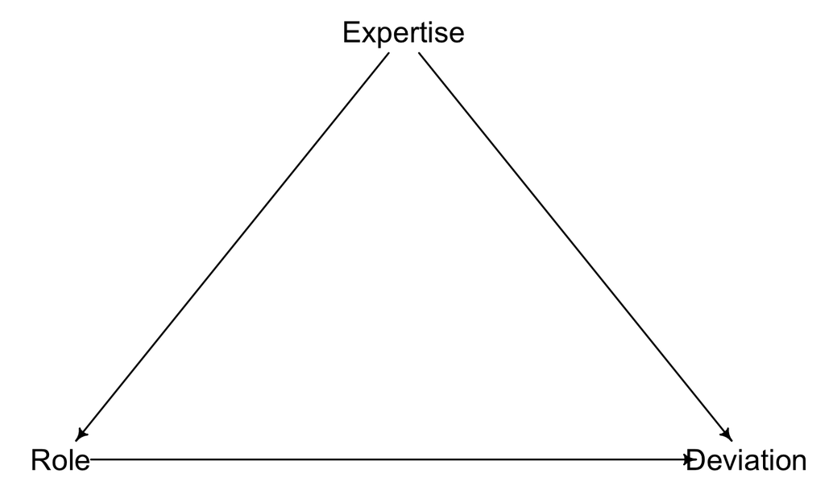

CIHR assigns the reviewer role partly *based on expertise*.

So **role is a mediator, not a confounder, of expertise’s effect** – and “adjusting for everything” would answer a different question than the one we ask.

Focal exposure: **role**. Expertise is then a genuine confounder.

## Lesson 2: the estimand decides what the model can see

**Combining the two parts is a real decision**  
Averaging *signed* deviation can cancel to ≈ 0 even when groups differ a lot

**Location and spread are different questions**  
Panelists may sit lower, swing wider, or both

**Simulation makes that visible early**  
We now simulate both, and plan to report which survive in real data

Simulation calibrated to public CIHR information (committee sizes, reviewer workload) and to Johnson (2008).

## Why dedicated metaresearch funding matters

**Access**  
Partnership with the funder itself makes evaluating the funder’s own process possible

**Time to do it properly**  
Simulation, pre-specification and open code are slow – and rarely rewarded in project grants

**Open science with sensitive data**  
A reusable template for “open code, closed data” evaluation that other funders can adopt

## Thank you

**Sam Harper** – McGill University  
`sbh4th@gmail.com`

**Funded by**  
Research on Research Joint Initiative: SSHRC, CIHR, Michael Smith Health Research BC

Johnson, Valen E. 2008. “Statistical Analysis of the National Institutes of Health Peer Review System.” *Proceedings of the National Academy of Sciences* 105 (32): 11076–80. https://doi.org/10.1073/pnas.0804538105.